# Introduction to R and SQL

Ana and Parth

February 4, 2015

This is an introductory step by step guide in creating your first R project and developing data visualization plots. You will also get a brief glipse into SQL through the use of SQL queries in RStudio.

## Getting Started - Create an R Project

Open RStudio and create a new project. Locate the Project dropdown menu in the top right side of the screen. Select ‘New Project…’

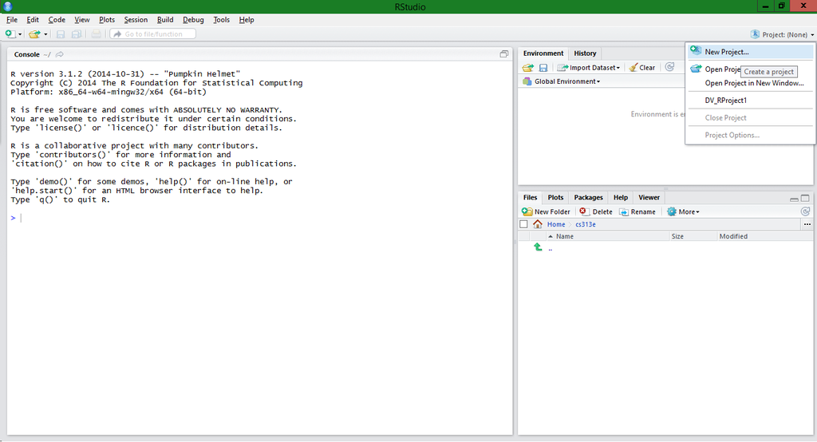

Create the Project in a preffered directory. Add three folders to the directory: - 00 Doc - 01 Data - 02 Visualizations

## Creating Dataframes

There are four different data structures stored on the RestfulRel Server that we need to access for this project. The data will be stored in dataframes.

To access the data, a call is made to request the information. The code to associate the SQL query to a defined variable in R looks like this:

```
df <- data.frame(eval(parse(text=substring(getURL(URLencode('http://129.152.144.84:5001/rest/native/?query="yourQuery"'), httpheader=c(DB='jdbc:oracle:thin:@129.152.144.84:1521/PDB1.usuniversi01134.oraclecloud.internal', USER='DV_ORDERS', PASS='orcl', MODE='native_mode', MODEL='model', returnFor = 'R', returnDimensions = 'False'), verbose = TRUE), 1, 2^31-1))))
```

The SQL query can be inputted where “yourQuery” is located in the above R code.

In our case, the queries sent are as follow: - select * from customers - select * from orders - select * from order_details - select * from items

The dataframes created and the outputs can be seen below.

#### Library Calls

```r
library("RCurl")
```

```r
library("ggplot2")
```

#### Customers Dataframe

```r
source("../01 Data/create_customers.R", echo = TRUE)
```

```
##
## > df_customers <- data.frame(eval(parse(text = substring(getURL(URLencode("http://129.152.144.84:5001/rest/native/?query=\"select * from customers\"") .... [TRUNCATED]
##
## > head(df_customers)
##   CUSTOMER_ID CUSTOMER_FIRST_NAME CUSTOMER_LAST_NAME      CUSTOMER_ADDRESS
## 1           1               Korah             Blanca       1555 W Lane Ave
## 2           2                Yash            Randall 11 E Rancho Madera Rd
## 3           3           Johnathon          Millerton        60 Madison Ave
## 4           4             Mikayla             Damion      2021 K Street Nw
## 5           5             Kendall              Mayte 4775 E Miami River Rd
## 6           6             Kaitlin           Hostlery 3250 Spring Grove Ave
##   CUSTOMER_CITY CUSTOMER_STATE CUSTOMER_ZIP CUSTOMER_PHONE CUSTOMER_FAX
## 1      Columbus             OH        43221     6145554432   6145553920
## 2       Madison             WI        53707     2095551205   2095552262
## 3      New York             NY        10010     2125554800         NULL
## 4    Washington             DC        20006     2025555561         NULL
## 5        Cleves             OH        45002     5135553024         NULL
## 6    Cincinnati             OH        45225     8005552128   8005552640
```

#### Orders Dataframe

```r
source("../01 Data/create_orders.R", echo = TRUE)
```

```
##
## > df_orders <- data.frame(eval(parse(text = substring(getURL(URLencode("http://129.152.144.84:5001/rest/native/?query=\"select * from orders\""),
## +   .... [TRUNCATED]
##
## > head(df_orders)
##   ORDER_ID CUSTOMER_ID          ORDER_DATE        SHIPPED_DATE
## 1       19           1 2012-10-23 00:00:00 2012-10-28 00:00:00
## 2       29           8 2012-11-05 00:00:00 2012-11-11 00:00:00
## 3       32          11 2012-11-10 00:00:00 2012-11-13 00:00:00
## 4       45           2 2012-11-25 00:00:00 2012-11-30 00:00:00
## 5       70          10 2012-12-28 00:00:00 2013-01-07 00:00:00
## 6       89          22 2013-01-20 00:00:00 2013-01-22 00:00:00
```

#### Order Details Dataframe

```r
source("../01 Data/create_order_details.R", echo = TRUE)
```

```
##
## > df_order_details <- data.frame(eval(parse(text = substring(getURL(URLencode("http://129.152.144.84:5001/rest/native/?query=\"select * from order_det .... [TRUNCATED]
##
## > head(df_order_details)
##   ORDER_ID ITEM_ID ORDER_QTY
## 1      381       1         1
## 2      601       9         1
## 3      442       1         1
## 4      523       9         1
## 5      630       5         1
## 6      778       1         1
```

#### Items Dataframe

```r
source("../01 Data/create_items.R", echo = TRUE)
```

```
##
## > df_items <- data.frame(eval(parse(text = substring(getURL(URLencode("http://129.152.144.84:5001/rest/native/?query=\"select * from items\""),
## +     .... [TRUNCATED]
##
## > head(df_items)
##   ITEM_ID                                       TITLE
## 1       1                            Umami In Concert
## 2       2                             Race Car Sounds
## 3       3                       No Rest For The Weary
## 4       4 More Songs About Structures and Comestibles
## 5       5               On The Road With Burt Ruggles
## 6       6                            No Fixed Address
##                  ARTIST UNIT_PRICE
## 1                 Umami         17
## 2         The Ubernerds         13
## 3 No Rest For The Weary         16
## 4 No Rest For The Weary         17
## 5          Burt Ruggles         17
## 6 Sewed the Vest Pocket         16
```

### The Combined Dataframe

One more dataframe will be constructed, but the data will be sourced from all of the previous tables. The SQL query used for this data frame is much more complex.

```
select * from orders o join customers c on o.customer_id = c.customer_id join order_details d on o.order_id = d.order_id
join items i on d.item_id = i.item_id
```

This data frame looks like this:

```r
source("../01 Data/create_combined.R", echo = TRUE)
```

```
##
## > df_combined <- data.frame(eval(parse(text = substring(getURL(URLencode("http://129.152.144.84:5001/rest/native/?query=\"select * from orders o join  .... [TRUNCATED]
##
## > head(df_combined)
##   ORDER_ID CUSTOMER_ID          ORDER_DATE        SHIPPED_DATE
## 1      550          17 2014-03-23 00:00:00 2014-04-03 00:00:00
## 2      298          18 2013-08-18 00:00:00 2013-09-22 00:00:00
## 3      242          23 2013-06-24 00:00:00 2013-07-06 00:00:00
## 4      829           9 2014-08-02 00:00:00                null
## 5       70          10 2012-12-28 00:00:00 2013-01-07 00:00:00
## 6      800          19 2014-07-21 00:00:00 2014-07-28 00:00:00
##   CUSTOMER_ID.1 CUSTOMER_FIRST_NAME CUSTOMER_LAST_NAME
## 1            17              Samuel           Jacobsen
## 2            18              Justin              Javen
## 3            23              Trisha               Anum
```

[output cut: 24 more lines]

## Plots

Now we will create a few interesting plots using the data we have stored from the database.

### Ship Date vs. Order Date for Unit Price faceted by State

This plot takes the Order Date and Shipped Date in the x and y, respectively. The plot then color codes according to Unit Price and then facets to produce a different plot for each state.

```
##
## > p1 <- ggplot(df_combined, aes(x = as.Date(ORDER_DATE,
## +     "%Y-%m-%d"), y = as.Date(SHIPPED_DATE, "%Y-%m-%d"))) + geom_point(aes(color = as.factor .... [TRUNCATED]
##
## > p1 + facet_wrap(~CUSTOMER_STATE)
```

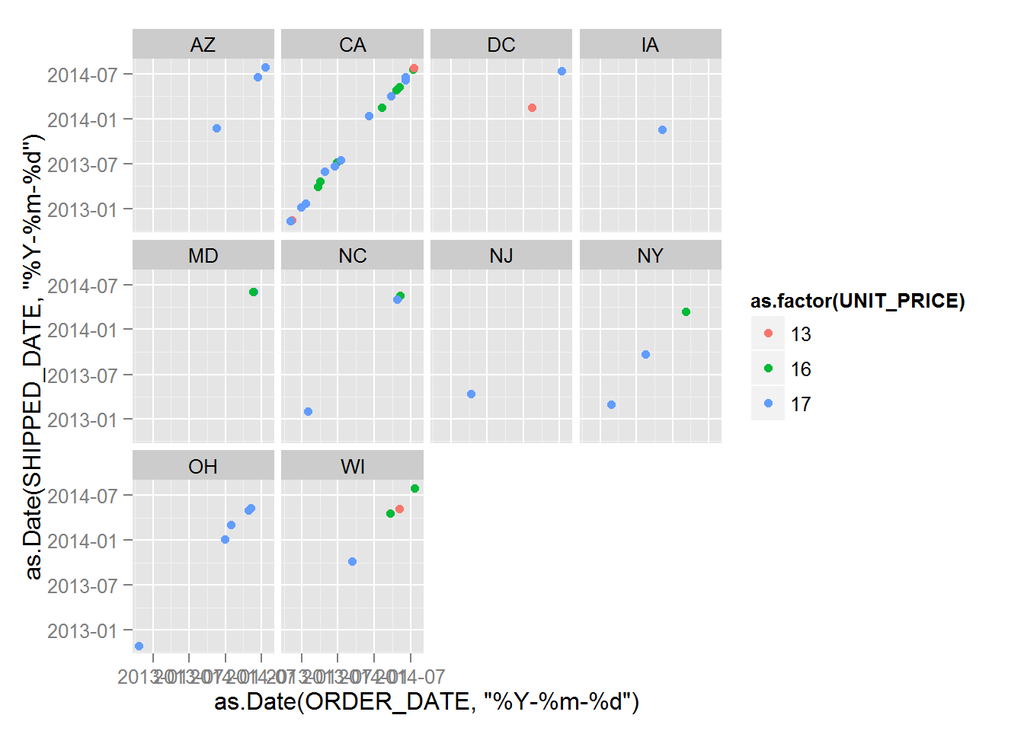

```r
source("../02 Visualizations/plot 1.R", echo = TRUE)
```

### Ship Date vs. Order Date for Item Title faceted by State

This plot takes the Order Date and Shipped Date in the x and y, respectively. The plot then color codes according to the title of the item purchased and then facets to produce a different plot for each state.

```
##
## > p2 <- ggplot(df_combined, aes(x = as.Date(ORDER_DATE,
## +     "%Y-%m-%d"), y = as.Date(SHIPPED_DATE, "%Y-%m-%d"))) + geom_point(aes(color = as.factor .... [TRUNCATED]
##
## > p2 + facet_wrap(~CUSTOMER_STATE)
```

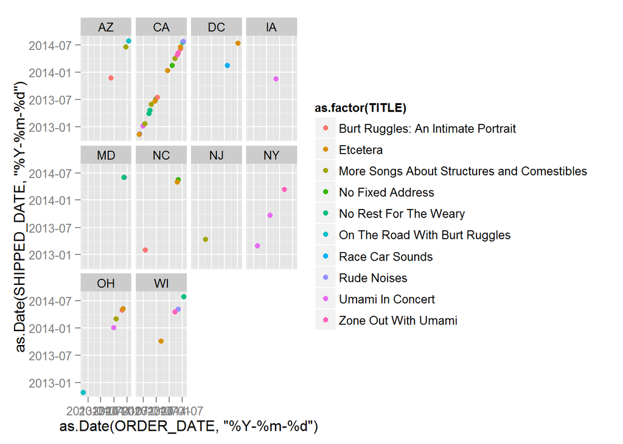

```r
source("../02 Visualizations/plot 2.R", echo = TRUE)
```

### Ship Date vs. Order Date for Item Artist faceted by State

This plot takes the Order Date and Shipped Date in the x and y, respectively. The plot then color codes according to the artist of each album (item) purchased and then facets to produce a different plot for each state.

```
##
## > p3 <- ggplot(df_combined, aes(x = as.Date(ORDER_DATE,
## +     "%Y-%m-%d"), y = as.Date(SHIPPED_DATE, "%Y-%m-%d"))) + geom_point(aes(color = ARTIST))
##
## > p3 + facet_wrap(~CUSTOMER_STATE)
```

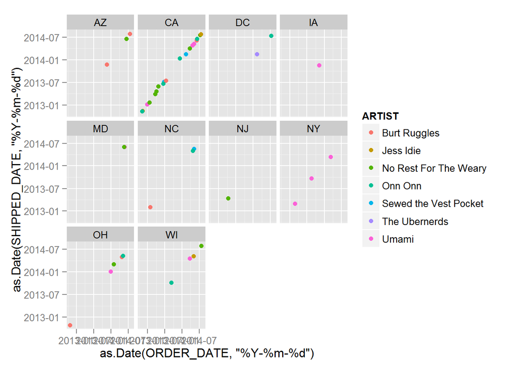

```r
source("../02 Visualizations/plot 3.R", echo = TRUE)
```

### Customer City vs. Customer State

```
##
## > p4 <- ggplot(df_customers, aes(x = as.factor(CUSTOMER_STATE),
## +     y = as.factor(CUSTOMER_CITY))) + geom_point()
##
## > p4
```

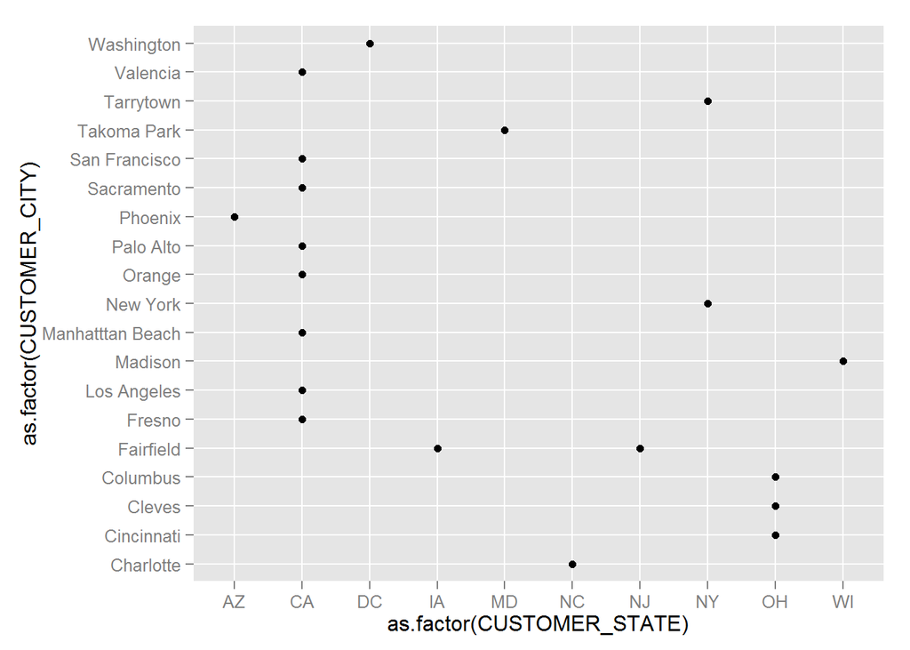

```r
source("../02 Visualizations/plot 4.R", echo = TRUE)
```

### Order Date vs. Shipped Date according to Customer ID

This plot takes the Order Date and Shipped Date in the x and y, respectively. The plot then color codes according to the customer ID.

```
##
## > p5 <- ggplot(df_orders, aes(x = as.Date(ORDER_DATE,
## +     "%Y-%m-%d"), y = as.Date(SHIPPED_DATE, "%Y-%m-%d"))) + geom_point(aes(color = as.factor(C .... [TRUNCATED]
##
## > p5
```

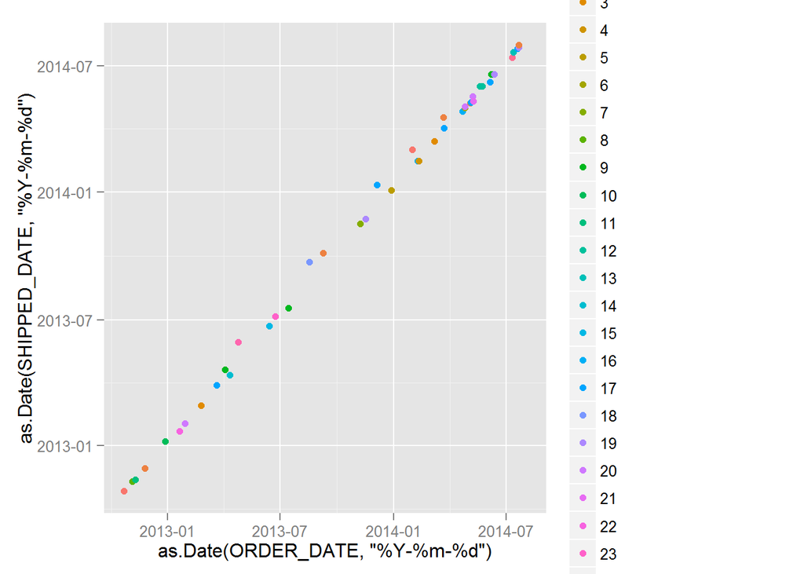

```r
source("../02 Visualizations/plot 5.R", echo = TRUE)
```

### Item ID vs. Order Quantity

First, the Order Details DataFrame is modified to instead count the number of orders made per item and the quantity ordered.

As mentioned previously, `yourQuery` is replaced with `select ITEM_ID, count(ORDER_ID) orderid_count, sum(ORDER_QTY) qty_sum from order_details group by ITEM_ID`.

```r
source ("../01 Data/order_details2.R", echo = TRUE)
```

```
##
## > df_order_details2 <- data.frame(eval(parse(text = substring(getURL(URLencode("http://129.152.144.84:5001/rest/native/?query=\"select ITEM_ID, count( .... [TRUNCATED]
##
## > head(df_order_details2)
##   ITEM_ID ORDERID_COUNT QTY_SUM
## 1       1            12      13
## 2       6             6       7
## 3       2             4       4
## 4       5             6       6
## 5       4             8       8
## 6       8             5       5
```

The following plot takes the Item ID as the x axis and total number of items ordered as the y axis. Using this plot, popularity of items can be shown by the total quantity ordered.

```
##
## > p6 <- ggplot(df_order_details2, aes(x = ITEM_ID, y = QTY_SUM)) +
## +     geom_point()
##
## > p6
```

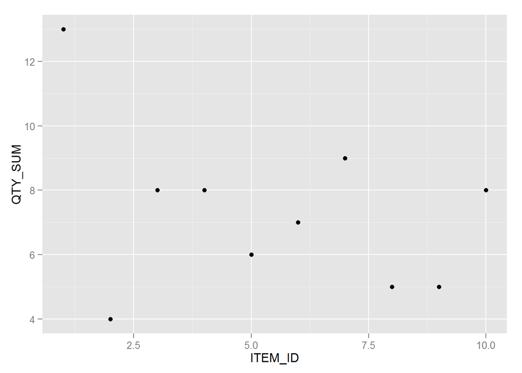

```r
source ("../02 Visualizations/plot 6.R", echo = TRUE)
```

### Artist vs Unit Price of Various Titles

Using the Items DataFrame for this plot, the Artist and Unit Price are graphed on the x and y axes respecitively with the Title as the key. The colors are according to the Title of the item and shows some Artists had more than one Title that also varied in price.

Take for example, “No Rest For The Weary” who had the two titles, “No Rest For The Weary” and “More Songs About Structures and Comestibles”, that had different prices per unit of 16 and 17, respectively.

```
##
## > p7 <- ggplot(df_items, aes(x = ARTIST, y = as.factor(UNIT_PRICE),
## +     color = TITLE)) + geom_point()
##
## > p7
```

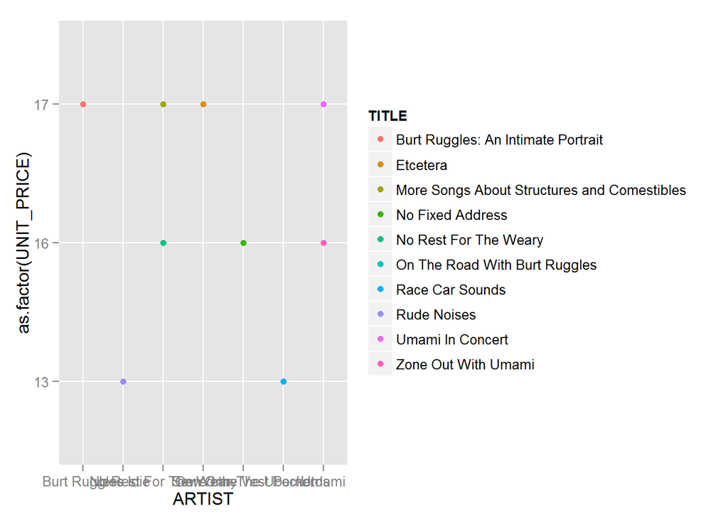

```r
source("../02 Visualizations/plot 7.R", echo = TRUE)
```